# problemB

1. Import Necessary Libraries

```python
# In[1]: Import necessary libraries
import pandas as pd
import numpy as np
import matplotlib.pyplot as plt
import seaborn as sns
from sklearn.model_selection import train_test_split
from sklearn.ensemble import RandomForestRegressor
from sklearn.metrics import mean_squared_error, r2_score
```

2. Load the Dataset

```python
# In[2]: Load the dataset
data = pd.read_csv('C:/Users/Admin/Documents/MLAI/CSCN8030/Proje6/problem1.csv')

# Display first few rows to understand its structure
data.head()
```

|  | number_people | date | timestamp | day_of_week | is_weekend | is_holiday | temperature | is_start_of_semester | is_during_semester | month | hour |
| --- | --- | --- | --- | --- | --- | --- | --- | --- | --- | --- | --- |
| 0 | 37 | 2015-08-14 17:00:11-07:00 | 61211 | 4 | 0 | 0 | 71.76 | 0 | 0 | 8 | 17 |
| 1 | 45 | 2015-08-14 17:20:14-07:00 | 62414 | 4 | 0 | 0 | 71.76 | 0 | 0 | 8 | 17 |
| 2 | 40 | 2015-08-14 17:30:15-07:00 | 63015 | 4 | 0 | 0 | 71.76 | 0 | 0 | 8 | 17 |
| 3 | 44 | 2015-08-14 17:40:16-07:00 | 63616 | 4 | 0 | 0 | 71.76 | 0 | 0 | 8 | 17 |
| 4 | 45 | 2015-08-14 17:50:17-07:00 | 64217 | 4 | 0 | 0 | 71.76 | 0 | 0 | 8 | 17 |

3. Display Column Names and Data Types

```python
#  Display column names and data types
data.info()
```

```
<class 'pandas.core.frame.DataFrame'>
RangeIndex: 62184 entries, 0 to 62183
Data columns (total 11 columns):
 #   Column                Non-Null Count  Dtype
---  ------                --------------  -----
 0   number_people         62184 non-null  int64
 1   date                  62184 non-null  object
 2   timestamp             62184 non-null  int64
 3   day_of_week           62184 non-null  int64
 4   is_weekend            62184 non-null  int64
 5   is_holiday            62184 non-null  int64
 6   temperature           62184 non-null  float64
 7   is_start_of_semester  62184 non-null  int64
 8   is_during_semester    62184 non-null  int64
 9   month                 62184 non-null  int64
 10  hour                  62184 non-null  int64
dtypes: float64(1), int64(9), object(1)
memory usage: 5.2+ MB
```

4. Check for Missing Values

```python
# Check for missing values
data.isnull().sum()
```

```
number_people           0
date                    0
timestamp               0
day_of_week             0
is_weekend              0
is_holiday              0
temperature             0
is_start_of_semester    0
is_during_semester      0
month                   0
hour                    0
dtype: int64
```

5. Handle Missing Values

```python
#Drop rows with missing values in 'date' column (if any)
data = data.dropna(subset=['date'])
```

6. Check for Duplicate Rows

```python
#Check for duplicate rows
data.duplicated().sum()
```

```
0
```

8. Convert 'date' Column to Datetime Format

```python
#  Convert 'date' column to datetime format
data['date'] = pd.to_datetime(data['date'], errors='coerce')
```

9. Handle Missing Values in 'date' Column

```python
# Handle missing values in 'date' column if necessary
# Check the type of 'date' column
print(data['date'].dtype)
# Convert 'date' column to datetime format
data['date'] = pd.to_datetime(data['date'], errors='coerce')

# Check again to confirm the conversion
print(data['date'].dtype)
# Drop rows with invalid dates if conversion fails
data = data.dropna(subset=['date'])
```

```
object
datetime64[ns, UTC-07:00]
```

10. Extract Time-Based Features from 'date'

```python
# Extract time-based features from 'date'
data['hour'] = data['date'].dt.hour
data['day_of_week'] = data['date'].dt.dayofweek
data['month'] = data['date'].dt.month

# Drop 'date' column
data = data.drop('date', axis=1)
```

11. Check the Updated Dataset

```python
# Check the updated dataset
data.head()
```

|  | number_people | timestamp | day_of_week | is_weekend | is_holiday | temperature | is_start_of_semester | is_during_semester | month | hour |
| --- | --- | --- | --- | --- | --- | --- | --- | --- | --- | --- |
| 0 | 37 | 61211 | 4 | 0 | 0 | 71.76 | 0 | 0 | 8 | 17 |
| 1 | 45 | 62414 | 4 | 0 | 0 | 71.76 | 0 | 0 | 8 | 17 |
| 2 | 40 | 63015 | 4 | 0 | 0 | 71.76 | 0 | 0 | 8 | 17 |
| 3 | 44 | 63616 | 4 | 0 | 0 | 71.76 | 0 | 0 | 8 | 17 |
| 4 | 45 | 64217 | 4 | 0 | 0 | 71.76 | 0 | 0 | 8 | 17 |

12. Define Features and Target

```python
# Define features and target
X = data.drop('number_people', axis=1)
y = data['number_people']
```

13. Split the Data into Training and Test Sets

```python
# Split the data into training and test sets
X_train, X_test, y_train, y_test = train_test_split(X, y, test_size=0.2, random_state=42)
```

14. Train a Random Forest Model

```python
# Train a Random Forest model
model = RandomForestRegressor(random_state=42)
model.fit(X_train, y_train)
```

```
RandomForestRegressor(random_state=42)
```

15. Make Predictions

```python
# Make predictions
y_pred = model.predict(X_test)
```

16. Evaluate the Model

```python
# Evaluate the model
mse = mean_squared_error(y_test, y_pred)
r2 = r2_score(y_test, y_pred)

print(f"Mean Squared Error: {mse}")
print(f"R^2 Score: {r2}")
```

```
Mean Squared Error: 41.36535401064666
R^2 Score: 0.9148235956496694
```

17. Feature Importance

```python
# Feature importance
importances = model.feature_importances_
features = X.columns
importance_df = pd.DataFrame({'Feature': features, 'Importance': importances})
importance_df = importance_df.sort_values(by='Importance', ascending=False)
```

18. Plot Feature Importances

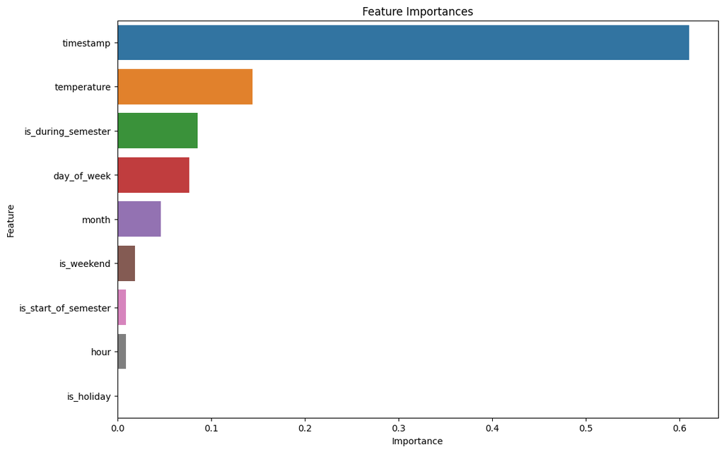

```python
# Plot feature importances
plt.figure(figsize=(12, 8))
sns.barplot(x='Importance', y='Feature', data=importance_df)
plt.title('Feature Importances')
plt.show()
```

19. Visualization of Predictions vs Actual Values

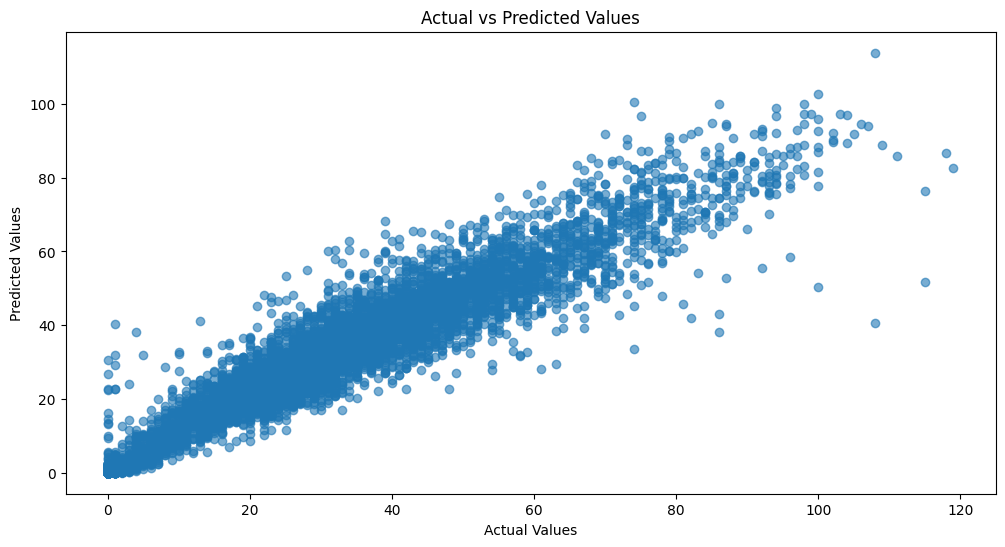

```python
# Visualization of predictions vs actual values
plt.figure(figsize=(12, 6))
plt.scatter(y_test, y_pred, alpha=0.6)
plt.xlabel('Actual Values')
plt.ylabel('Predicted Values')
plt.title('Actual vs Predicted Values')
plt.show()
```

20. Analyze Residuals

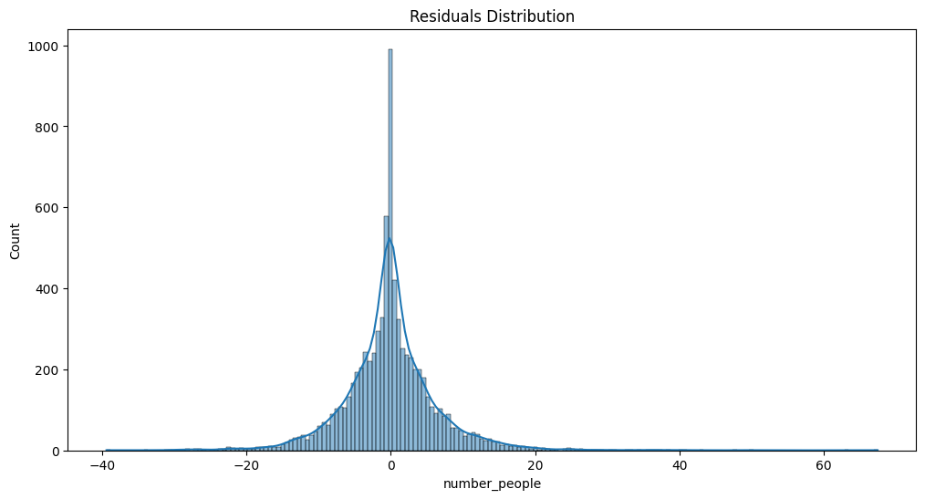

```python
#Analyze residuals
residuals = y_test - y_pred
plt.figure(figsize=(12, 6))
sns.histplot(residuals, kde=True)
plt.title('Residuals Distribution')
plt.show()
```

- *In a correlation matrix, the inclusion of the timestamp variable is generally not useful or necessary because timestamp is a temporal feature that represents the point in time at which the observation was recorded.*
- *We’ve identified that is_holiday is not an important feature for our analysis, so we you can exclude it from the correlation matrix as well*

```python
# Exclude 'timestamp' from the correlation matrix
features_to_exclude = ['timestamp', 'is_holiday']
Data_dropped = data.drop(features_to_exclude, axis=1)
```

21. Correlation Matrix

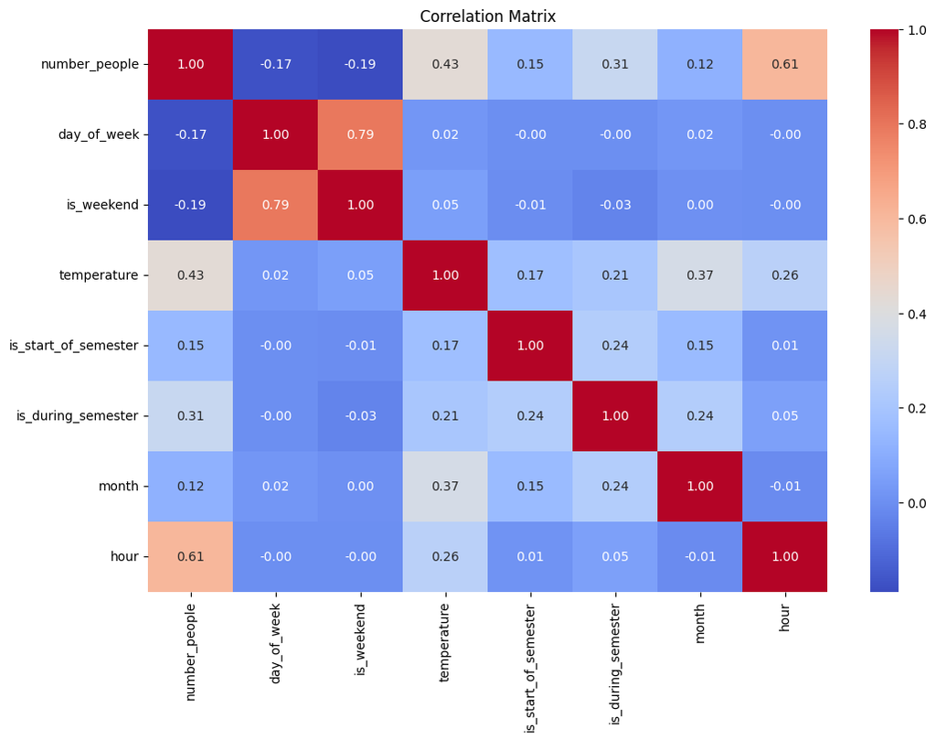

```python
# Correlation matrix
corr_matrix = data.drop(features_to_exclude, axis=1).corr()

plt.figure(figsize=(12, 8))
sns.heatmap(corr_matrix, annot=True, cmap='coolwarm', fmt='.2f')
plt.title('Correlation Matrix')
plt.show()
```

22. Advanced Analysis: Average Number of People by Hour

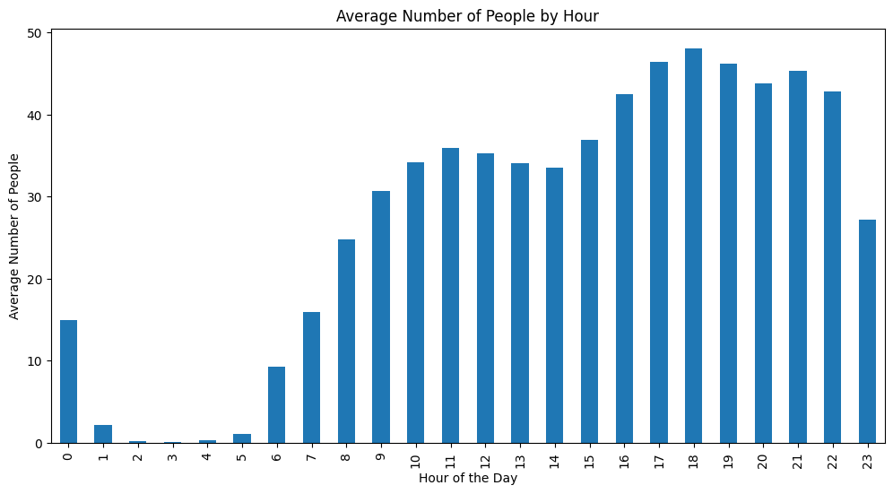

```python
# Advanced analysis - Average number of people by hour
hourly_data = Data_dropped.groupby('hour')['number_people'].mean()
plt.figure(figsize=(12, 6))
hourly_data.plot(kind='bar')
plt.title('Average Number of People by Hour')
plt.xlabel('Hour of the Day')
plt.ylabel('Average Number of People')
plt.show()
```

23. Advanced Analysis: Average Number of People by Day of the Week

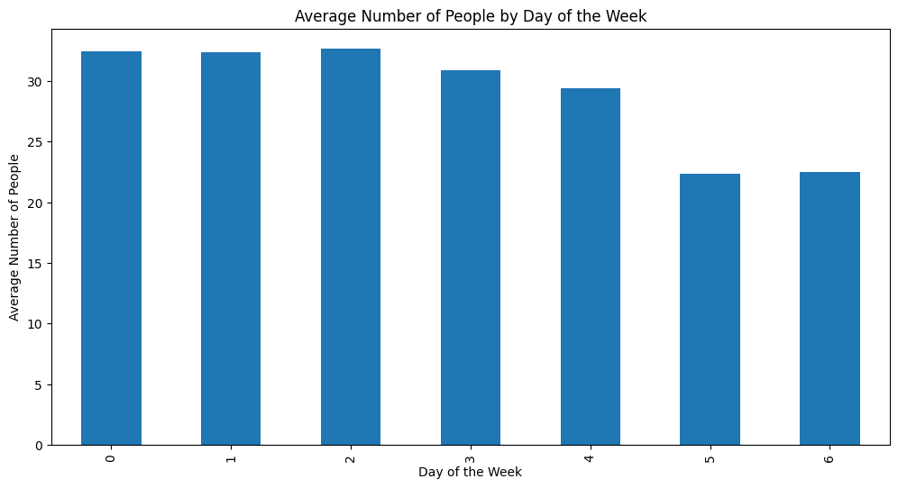

```python
# Advanced analysis - Average number of people by day of the week
daily_data = Data_dropped.groupby('day_of_week')['number_people'].mean()
plt.figure(figsize=(12, 6))
daily_data.plot(kind='bar')
plt.title('Average Number of People by Day of the Week')
plt.xlabel('Day of the Week')
plt.ylabel('Average Number of People')
plt.show()
```

24. Advanced Analysis: Average Number of People by Month

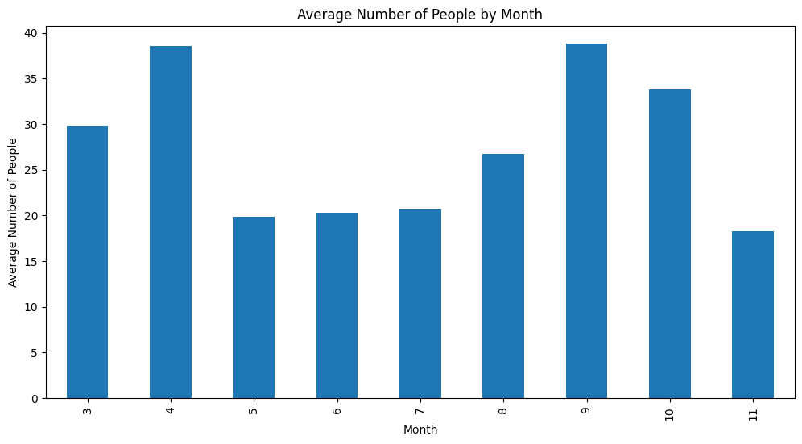

```python
# Advanced analysis - Average number of people by month
monthly_data = Data_dropped.groupby('month')['number_people'].mean()
plt.figure(figsize=(12, 6))
monthly_data.plot(kind='bar')
plt.title('Average Number of People by Month')
plt.xlabel('Month')
plt.ylabel('Average Number of People')
plt.show()
```

4. Univariate Analysis

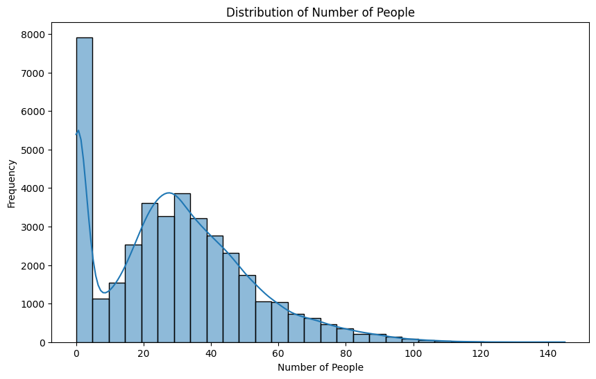

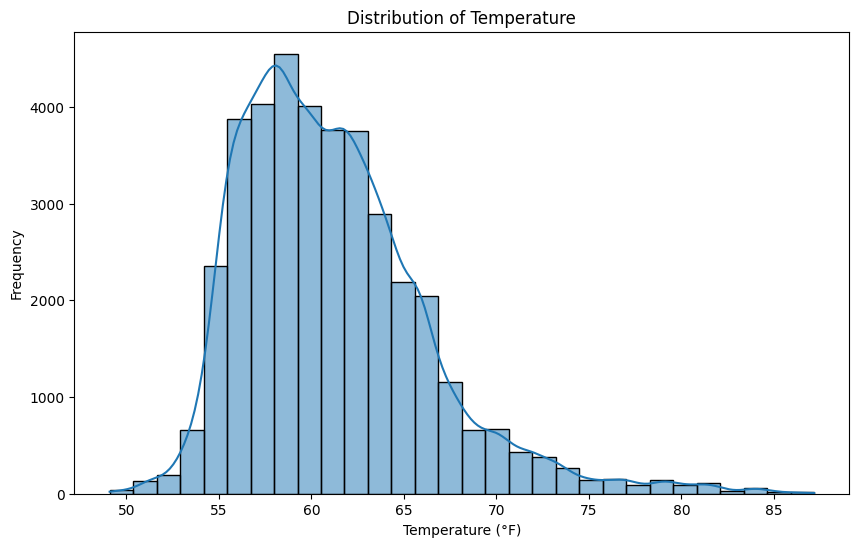

```python
# Distribution of 'number_of_people'

plt.figure(figsize=(10, 6))
sns.histplot(Data_dropped['number_people'], bins=30, kde=True)
plt.title('Distribution of Number of People')
plt.xlabel('Number of People')
plt.ylabel('Frequency')
plt.show()

# Distribution of 'temperature'
plt.figure(figsize=(10, 6))
sns.histplot(Data_dropped['temperature'], bins=30, kde=True)
plt.title('Distribution of Temperature')
plt.xlabel('Temperature (°F)')
plt.ylabel('Frequency')
plt.show()
```

5. Bivariate Analysis

```
Index(['number_people', 'day_of_week', 'is_weekend', 'temperature',
       'is_start_of_semester', 'is_during_semester', 'month', 'hour'],
      dtype='object')
```

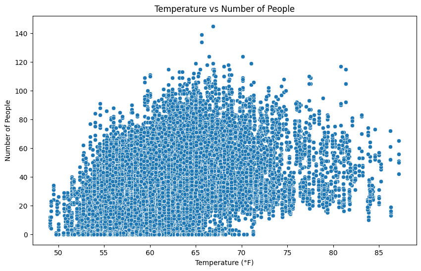

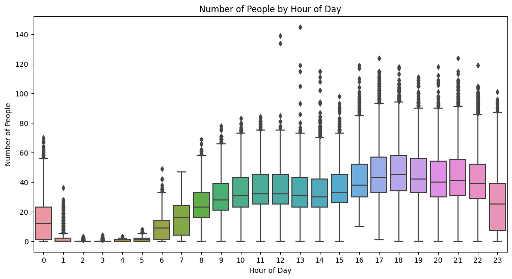

```python
import matplotlib.pyplot as plt
import seaborn as sns

# Verify the DataFrame columns
print(Data_dropped.columns)

# Scatter Plot: Temperature vs Number of People
plt.figure(figsize=(10, 6))
sns.scatterplot(x='temperature', y='number_people', data=Data_dropped)
plt.title('Temperature vs Number of People')
plt.xlabel('Temperature (°F)')
plt.ylabel('Number of People')
plt.show()

# Box Plot: Number of People by Hour of Day
plt.figure(figsize=(12, 6))
sns.boxplot(x='hour', y='number_people', data=Data_dropped)
plt.title('Number of People by Hour of Day')
plt.xlabel('Hour of Day')
plt.ylabel('Number of People')
plt.show()
```

6. Time Series Analysis

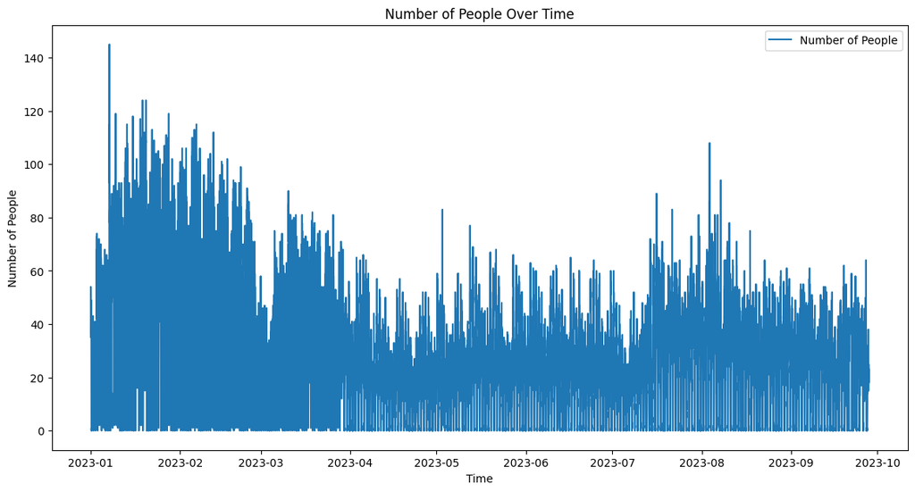

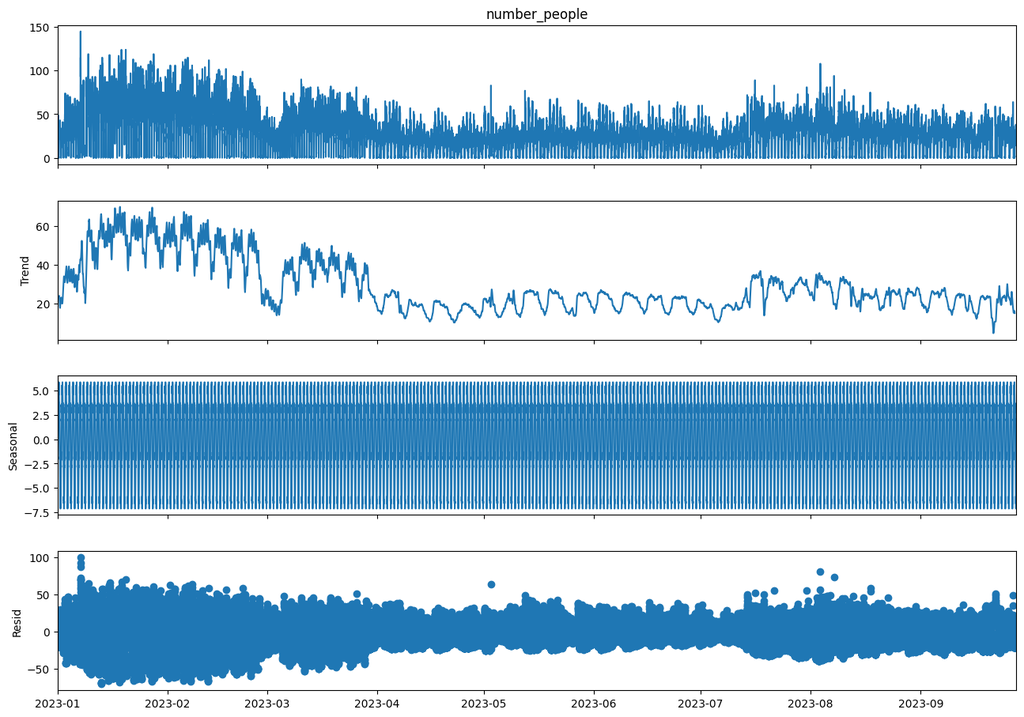

```python
import pandas as pd
import matplotlib.pyplot as plt
from statsmodels.tsa.seasonal import seasonal_decompose

# Assume 'data' is your DataFrame
# Generate a datetime range
start_date = '2023-01-01'  # Update with the actual start date of your data
n_periods = len(data)  # Number of periods (rows) in your data
date_range = pd.date_range(start=start_date, periods=n_periods, freq='10T')  # 10 minutes frequency

# Add the datetime index to the DataFrame
data['timestamp'] = date_range
data.set_index('timestamp', inplace=True)

# Convert the index to datetime (if necessary)
data.index = pd.to_datetime(data.index)

# Plot time series of 'number_people'
plt.figure(figsize=(14, 7))
plt.plot(data.index, data['number_people'], label='Number of People')
plt.title('Number of People Over Time')
plt.xlabel('Time')
plt.ylabel('Number of People')
plt.legend()
plt.show()

# Decompose the time series
decomposition = seasonal_decompose(data['number_people'], model='additive', period=144)  # 144 ten-minute intervals in a day

# Plot decomposition
fig = decomposition.plot()
fig.set_size_inches(14, 10)
plt.show()
```

7. Advanced Visualization

```
Index(['number_people', 'day_of_week', 'is_weekend', 'is_holiday',
       'temperature', 'is_start_of_semester', 'is_during_semester', 'month',
       'hour'],
      dtype='object')
```

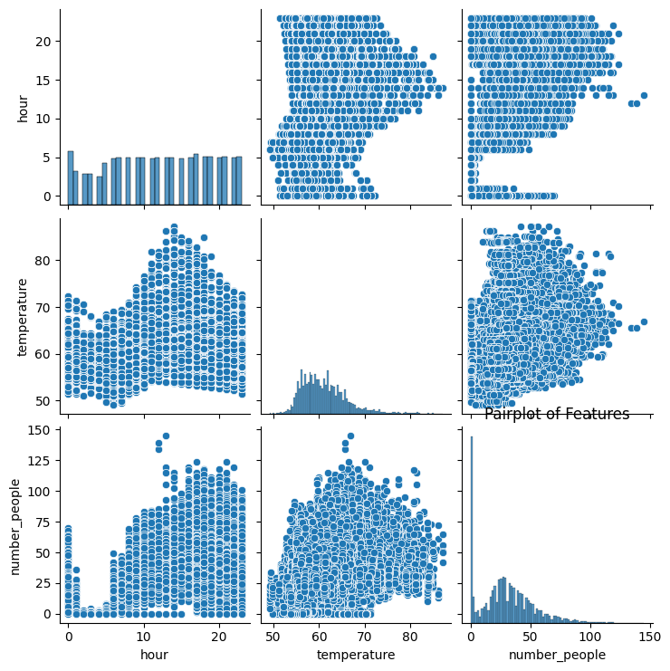

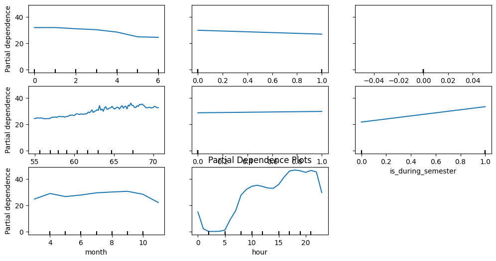

```python
from sklearn.inspection import PartialDependenceDisplay
# Check the columns
print(data.columns)

# Use the correct column names
feature_column = 'number_people'  # Update this if necessary

# Pairplot to examine relationships between features
sns.pairplot(data, vars=['hour', 'temperature', feature_column])
plt.title('Pairplot of Features')
plt.show()

# Train a RandomForest model
rf_model = RandomForestRegressor(n_estimators=100, random_state=42)
X = data.drop(feature_column, axis=1)
y = data[feature_column]
rf_model.fit(X, y)

# Plot Partial Dependence
fig, ax = plt.subplots(figsize=(12, 6))
PartialDependenceDisplay.from_estimator(rf_model, X, features=X.columns, ax=ax)
plt.title('Partial Dependence Plots')
plt.show()
```